# relations paper

2025-01-14

### The dataset

```r
d <- read_sav(here("outcomes paper/data_outcomes", "p_y_w1_for_analysesjan25.sav")) # 94 rows

view_df(d)
```

Data frame: d

| ID | Name | Label | Values | Value Labels |
| --- | --- | --- | --- | --- |
| 1 | school_id |  | *range: 1-6* |  |
| 2 | condition |  | *range: 1-2* |  |
| 3 | family_id | Family ID - PJ - Text |  | <output omitted> |
| 4 | participant_id |  |  | <output omitted> |
| 5 | parent_role |  | 1 2 3 | 1 2 4 |
| 6 | parent_role_text |  |  |  |
| 7 | parent_age |  | *range: 28-76* |  |
| 8 | country_born | ¿Dónde nació usted? - País: - Text |  | <output omitted> |
| 9 | parent_ed |  | 1 2 3 4 | 1 2 3 4 |
| 10 | parent_eng_comf |  | 1 2 3 4 5 | 1 2 3 4 5 |
| 11 | youth_age | Edad de su joven: - Edad: - Text |  | <output omitted> |
| 12 | youth_country_born | Lugar de nacimiento de su joven: - País: - Text |  | <output omitted> |
| 13 | adults_at_home | ¿Cuántas personas actualmente viven en su hogar incluyendo usted (las personas que comen y duermen allí la mayor parte del tiempo)? - Número de adultos (mayores de 18 años): - Text |  | <output omitted> |
| 14 | minors_at_home | ¿Cuántas personas actualmente viven en su hogar incluyendo usted (las personas que comen y duermen allí la mayor parte del tiempo)? - Número de niños (menores de 18 años): - Text |  | <output omitted> |
| 15 | lang_arts |  | *range: 1-5* |  |
| 16 | soc_stu |  | *range: 1-4* |  |
| 17 | math |  | *range: 1-5* |  |
| 18 | science |  | *range: 1-4* |  |
| 19 | gen_grades |  | *range: 1-6* |  |
| 20 | help_extra |  | *range: 0-1* |  |
| 21 | attend_pta |  | *range: 0-1* |  |
| 22 | sats_contact |  | *range: 1-4* |  |
| 23 | acadhwi_1 |  | *range: 1.0-4.0* |  |
| 24 | checkhwi_1 |  | *range: 1.0-4.0* |  |
| 25 | struct_1 |  | *range: 1.6-4.0* |  |
| 26 | trust_1 |  | *range: 2.6-4.0* |  |
| 27 | convclimate_1 |  | *range: 1.5-4.0* |  |
| 28 | convsocial_1 |  | *range: 1.5-4.0* |  |
| 29 | convfut_1 |  | *range: 1.0-4.0* |  |
| 30 | futorient_1 |  | *range: 2.8-4.0* |  |
| 31 | knowschool_1 |  | *range: 1.0-4.0* |  |
| 32 | parnets_1 |  | *range: 1.0-4.0* |  |
| 33 | selfeffic_1 |  | *range: 2.2-4.0* |  |
| 34 | welcome_1 |  | *range: 2.2-4.0* |  |
| 35 | included_1 |  | *range: 1.0-4.0* |  |
| 36 | endorse_1 |  | *range: 2.0-4.0* |  |
| 37 | supported_1 |  | *range: 2.0-4.0* |  |
| 38 | ptrel_1 |  | *range: 2.0-4.0* |  |
| 39 | grade_lev |  | *range: 1-3* |  |
| 40 | grades |  | *range: 1-7* |  |
| 41 | youth_eng_comf |  | *range: 2-5* |  |
| 42 | youth_gender |  | *range: 1-2* |  |
| 43 | y_latino |  | *range: 1-1* |  |
| 44 | y_indigenous_americas |  | *range: 1-1* |  |
| 45 | y_race_ethnicity_no_response |  | *range: 1-1* |  |
| 46 | y_sch_eng |  | *range: 2.3-5.0* |  |
| 47 | y_parsupp |  | *range: 1.8-4.0* |  |
| 48 | y_parinv |  | *range: 1.0-4.0* |  |
| 49 | y_hw |  | *range: 1.3-4.0* |  |

```r
data.frame(table(d$family_id)) # no dupped ids
```

```
##    Var1 Freq
## 1   101    1
## 2   102    1
## 3   103    1
## 4   104    1
## 5   105    1
## 6   106    1
## 7   107    1
## 8   108    1
## 9   109    1
## 10  110    1
## 11  111    1
## 12  112    1
## 13  113    1
## 14  114    1
```

[output cut: 80 more lines]

CM suggested to standardize the betas, however:

```r
d1 <- d %>%
  mutate(parent_eng_comf = as.numeric(parent_eng_comf), # average comfort
         youth_gender = factor(youth_gender),
         youth_gender = relevel(youth_gender, ref = "1"), # male
         youth_age = as.numeric(youth_age)) # average youth age

view_df(d1)
```

Data frame: d1

| ID | Name | Label | Values | Value Labels |
| --- | --- | --- | --- | --- |
| 1 | school_id |  | *range: 1-6* |  |
| 2 | condition |  | *range: 1-2* |  |
| 3 | family_id | Family ID - PJ - Text |  | <output omitted> |
| 4 | participant_id |  |  | <output omitted> |
| 5 | parent_role |  | 1 2 3 | 1 2 4 |
| 6 | parent_role_text |  |  |  |
| 7 | parent_age |  | *range: 28-76* |  |
| 8 | country_born | ¿Dónde nació usted? - País: - Text |  | <output omitted> |
| 9 | parent_ed |  | 1 2 3 4 | 1 2 3 4 |
| 10 | parent_eng_comf |  | *range: 1-5* |  |
| 11 | youth_age |  | *range: 10-13* |  |
| 12 | youth_country_born | Lugar de nacimiento de su joven: - País: - Text |  | <output omitted> |
| 13 | adults_at_home | ¿Cuántas personas actualmente viven en su hogar incluyendo usted (las personas que comen y duermen allí la mayor parte del tiempo)? - Número de adultos (mayores de 18 años): - Text |  | <output omitted> |
| 14 | minors_at_home | ¿Cuántas personas actualmente viven en su hogar incluyendo usted (las personas que comen y duermen allí la mayor parte del tiempo)? - Número de niños (menores de 18 años): - Text |  | <output omitted> |
| 15 | lang_arts |  | *range: 1-5* |  |
| 16 | soc_stu |  | *range: 1-4* |  |
| 17 | math |  | *range: 1-5* |  |
| 18 | science |  | *range: 1-4* |  |
| 19 | gen_grades |  | *range: 1-6* |  |
| 20 | help_extra |  | *range: 0-1* |  |
| 21 | attend_pta |  | *range: 0-1* |  |
| 22 | sats_contact |  | *range: 1-4* |  |
| 23 | acadhwi_1 |  | *range: 1.0-4.0* |  |
| 24 | checkhwi_1 |  | *range: 1.0-4.0* |  |
| 25 | struct_1 |  | *range: 1.6-4.0* |  |
| 26 | trust_1 |  | *range: 2.6-4.0* |  |
| 27 | convclimate_1 |  | *range: 1.5-4.0* |  |
| 28 | convsocial_1 |  | *range: 1.5-4.0* |  |
| 29 | convfut_1 |  | *range: 1.0-4.0* |  |
| 30 | futorient_1 |  | *range: 2.8-4.0* |  |
| 31 | knowschool_1 |  | *range: 1.0-4.0* |  |
| 32 | parnets_1 |  | *range: 1.0-4.0* |  |
| 33 | selfeffic_1 |  | *range: 2.2-4.0* |  |
| 34 | welcome_1 |  | *range: 2.2-4.0* |  |
| 35 | included_1 |  | *range: 1.0-4.0* |  |
| 36 | endorse_1 |  | *range: 2.0-4.0* |  |
| 37 | supported_1 |  | *range: 2.0-4.0* |  |
| 38 | ptrel_1 |  | *range: 2.0-4.0* |  |
| 39 | grade_lev |  | *range: 1-3* |  |
| 40 | grades |  | *range: 1-7* |  |
| 41 | youth_eng_comf |  | *range: 2-5* |  |
| 42 | youth_gender |  |  | 1 2 |
| 43 | y_latino |  | *range: 1-1* |  |
| 44 | y_indigenous_americas |  | *range: 1-1* |  |
| 45 | y_race_ethnicity_no_response |  | *range: 1-1* |  |
| 46 | y_sch_eng |  | *range: 2.3-5.0* |  |
| 47 | y_parsupp |  | *range: 1.8-4.0* |  |
| 48 | y_parinv |  | *range: 1.0-4.0* |  |
| 49 | y_hw |  | *range: 1.3-4.0* |  |

```r
only_scales <- d1 %>%
  select(acadhwi_1, checkhwi_1, checkhwi_1, struct_1, convfut_1, knowschool_1, selfeffic_1, parnets_1, welcome_1, endorse_1, supported_1, ptrel_1)

# descrip_table <- descriptives(only_scales) %>%
#   rename(c("Scale" = "column"))
```

```r
library(Hmisc)
rcorr(as.matrix(only_scales), type = "pearson")
```

```
##              acadhwi_1 checkhwi_1 struct_1 convfut_1 knowschool_1 selfeffic_1
## acadhwi_1         1.00       0.22     0.47      0.26         0.34        0.35
## checkhwi_1        0.22       1.00     0.32      0.29         0.28        0.20
## struct_1          0.47       0.32     1.00      0.43         0.68        0.49
## convfut_1         0.26       0.29     0.43      1.00         0.46        0.31
## knowschool_1      0.34       0.28     0.68      0.46         1.00        0.52
## selfeffic_1       0.35       0.20     0.49      0.31         0.52        1.00
## parnets_1         0.52       0.22     0.45      0.30         0.37        0.21
## welcome_1         0.13       0.04     0.27      0.14         0.26        0.63
## endorse_1         0.22       0.16     0.36      0.20         0.35        0.72
## supported_1       0.12       0.18     0.33      0.24         0.29        0.57
## ptrel_1           0.26       0.10     0.44      0.35         0.38        0.56
##              parnets_1 welcome_1 endorse_1 supported_1 ptrel_1
## acadhwi_1         0.52      0.13      0.22        0.12    0.26
## checkhwi_1        0.22      0.04      0.16        0.18    0.10
## struct_1          0.45      0.27      0.36        0.33    0.44
## convfut_1         0.30      0.14      0.20        0.24    0.35
## knowschool_1      0.37      0.26      0.35        0.29    0.38
## selfeffic_1       0.21      0.63      0.72        0.57    0.56
## parnets_1         1.00     -0.08      0.10        0.05    0.15
## welcome_1        -0.08      1.00      0.73        0.72    0.55
## endorse_1         0.10      0.73      1.00        0.80    0.57
## supported_1       0.05      0.72      0.80        1.00    0.68
## ptrel_1           0.15      0.55      0.57        0.68    1.00
##
## n
##              acadhwi_1 checkhwi_1 struct_1 convfut_1 knowschool_1 selfeffic_1
## acadhwi_1           93         93       93        93           93          93
## checkhwi_1          93         93       93        93           93          93
## struct_1            93         93       94        94           94          94
## convfut_1           93         93       94        94           94          94
## knowschool_1        93         93       94        94           94          94
## selfeffic_1         93         93       94        94           94          94
## parnets_1           93         93       94        94           94          94
## welcome_1           93         93       94        94           94          94
## endorse_1           93         93       94        94           94          94
## supported_1         93         93       94        94           94          94
## ptrel_1             93         93       94        94           94          94
##              parnets_1 welcome_1 endorse_1 supported_1 ptrel_1
## acadhwi_1           93        93        93          93      93
```

[output cut: 21 more lines]

```
## endorse_1    0.0339    0.1202     0.0003   0.0569    0.0006       0.0000
## supported_1  0.2618    0.0777     0.0012   0.0181    0.0049       0.0000
## ptrel_1      0.0119    0.3386     0.0000   0.0005    0.0002       0.0000
##              parnets_1 welcome_1 endorse_1 supported_1 ptrel_1
## acadhwi_1    0.0000    0.2023    0.0339    0.2618      0.0119
## checkhwi_1   0.0373    0.7103    0.1202    0.0777      0.3386
## struct_1     0.0000    0.0082    0.0003    0.0012      0.0000
## convfut_1    0.0039    0.1667    0.0569    0.0181      0.0005
## knowschool_1 0.0003    0.0117    0.0006    0.0049      0.0002
## selfeffic_1  0.0433    0.0000    0.0000    0.0000      0.0000
## parnets_1              0.4438    0.3244    0.6277      0.1441
## welcome_1    0.4438              0.0000    0.0000      0.0000
## endorse_1    0.3244    0.0000              0.0000      0.0000
## supported_1  0.6277    0.0000    0.0000                0.0000
## ptrel_1      0.1441    0.0000    0.0000    0.0000
```

The expected school eng value is 2.46, when we consider average values of all predictors in the model and student is male.

For every one-point increase in checking hw, school eng increases, on average, 0.23 points

```r
# school engagement: youth report
m <- lm(y_sch_eng ~ acadhwi_1 + checkhwi_1 + struct_1 + convfut_1 + knowschool_1 + parnets_1 + welcome_1 + endorse_1 + supported_1 + ptrel_1, d1)
summary(m) # only checking hw came out significant 0.01
```

```
##
## Call:
## lm(formula = y_sch_eng ~ acadhwi_1 + checkhwi_1 + struct_1 +
##     convfut_1 + knowschool_1 + parnets_1 + welcome_1 + endorse_1 +
##     supported_1 + ptrel_1, data = d1)
##
## Residuals:
##      Min       1Q   Median       3Q      Max
## -1.19549 -0.29662 -0.00999  0.38060  1.00020
##
## Coefficients:
##                Estimate Std. Error t value Pr(>|t|)
## (Intercept)   3.1344803  0.5369662   5.837 1.02e-07 ***
## acadhwi_1    -0.0003091  0.0974877  -0.003   0.9975
## checkhwi_1    0.2201656  0.0865425   2.544   0.0128 *
## struct_1      0.1773251  0.1840409   0.964   0.3381
## convfut_1     0.0067985  0.0858634   0.079   0.9371
## knowschool_1  0.0347301  0.1417429   0.245   0.8071
## parnets_1     0.1192787  0.1146063   1.041   0.3010
## welcome_1     0.2594940  0.2081756   1.247   0.2161
## endorse_1     0.0014855  0.2357459   0.006   0.9950
## supported_1  -0.2536095  0.2555096  -0.993   0.3238
## ptrel_1      -0.2774740  0.1672138  -1.659   0.1009
## ---
## Signif. codes:  0 '***' 0.001 '**' 0.01 '*' 0.05 '.' 0.1 ' ' 1
##
## Residual standard error: 0.4952 on 82 degrees of freedom
##   (1 observation deleted due to missingness)
## Multiple R-squared:  0.2004, Adjusted R-squared:  0.1028
## F-statistic: 2.055 on 10 and 82 DF,  p-value: 0.03777
```

```r
m_cov <- lm(y_sch_eng ~ parent_eng_comf + youth_age + youth_gender + acadhwi_1 + checkhwi_1 + struct_1 + convfut_1 + knowschool_1 + parnets_1 + welcome_1 + endorse_1 + supported_1 + ptrel_1, d1)
summary(m_cov) # only checking hw came out significant 0.04
```

```
##
## Call:
## lm(formula = y_sch_eng ~ parent_eng_comf + youth_age + youth_gender +
##     acadhwi_1 + checkhwi_1 + struct_1 + convfut_1 + knowschool_1 +
##     parnets_1 + welcome_1 + endorse_1 + supported_1 + ptrel_1,
##     data = d1)
##
## Residuals:
##      Min       1Q   Median       3Q      Max
## -1.17577 -0.27176 -0.03908  0.30316  1.03043
##
## Coefficients:
##                  Estimate Std. Error t value Pr(>|t|)
## (Intercept)      2.460107   1.051577   2.339   0.0222 *
## parent_eng_comf -0.021437   0.044052  -0.487   0.6280
## youth_age        0.040187   0.073548   0.546   0.5865
## youth_gender2    0.164050   0.120472   1.362   0.1777
## acadhwi_1        0.033546   0.114479   0.293   0.7704
## checkhwi_1       0.231278   0.109482   2.112   0.0382 *
## struct_1         0.181507   0.199837   0.908   0.3668
## convfut_1       -0.008651   0.093808  -0.092   0.9268
## knowschool_1     0.024476   0.158595   0.154   0.8778
## parnets_1        0.118659   0.126989   0.934   0.3533
## welcome_1        0.292711   0.238063   1.230   0.2230
## endorse_1        0.092556   0.264937   0.349   0.7279
## supported_1     -0.285400   0.295536  -0.966   0.3375
## ptrel_1         -0.334375   0.191254  -1.748   0.0848 .
## ---
## Signif. codes:  0 '***' 0.001 '**' 0.01 '*' 0.05 '.' 0.1 ' ' 1
##
## Residual standard error: 0.5162 on 70 degrees of freedom
##   (10 observations deleted due to missingness)
## Multiple R-squared:  0.2239, Adjusted R-squared:  0.07981
## F-statistic: 1.554 on 13 and 70 DF,  p-value: 0.1204
```

The expected grades value is 4.50, when we consider average values of all predictors in the model and student is male, but is not significant.

no predictors in the model are significantly related to youth grades.

```r
# grades: youth report
m2 <- lm(grades ~ acadhwi_1 + checkhwi_1 + struct_1 + convfut_1 + knowschool_1 + parnets_1 + welcome_1 + endorse_1 + supported_1 + ptrel_1, d1)
summary(m2) # only conversation about future came out significant 0.02
```

```
##
## Call:
## lm(formula = grades ~ acadhwi_1 + checkhwi_1 + struct_1 + convfut_1 +
##     knowschool_1 + parnets_1 + welcome_1 + endorse_1 + supported_1 +
##     ptrel_1, data = d1)
##
## Residuals:
##     Min      1Q  Median      3Q     Max
## -1.9282 -0.6716 -0.2267  0.4946  3.4030
##
## Coefficients:
##              Estimate Std. Error t value Pr(>|t|)
## (Intercept)   3.15305    1.28836   2.447   0.0166 *
## acadhwi_1    -0.01360    0.24220  -0.056   0.9554
## checkhwi_1   -0.02130    0.20267  -0.105   0.9166
## struct_1     -0.42186    0.43399  -0.972   0.3340
## convfut_1    -0.48590    0.20199  -2.406   0.0185 *
## knowschool_1  0.47044    0.32900   1.430   0.1567
## parnets_1     0.07538    0.27815   0.271   0.7871
## welcome_1     0.45329    0.49546   0.915   0.3631
## endorse_1    -0.21149    0.56502  -0.374   0.7092
## supported_1  -0.74228    0.64372  -1.153   0.2524
## ptrel_1       0.70346    0.42308   1.663   0.1004
## ---
## Signif. codes:  0 '***' 0.001 '**' 0.01 '*' 0.05 '.' 0.1 ' ' 1
##
## Residual standard error: 1.147 on 78 degrees of freedom
##   (5 observations deleted due to missingness)
## Multiple R-squared:  0.1248, Adjusted R-squared:  0.01255
## F-statistic: 1.112 on 10 and 78 DF,  p-value: 0.3642
```

```r
m2_cov <- lm(grades ~ parent_eng_comf + youth_age + youth_gender + acadhwi_1 + checkhwi_1 + struct_1 + convfut_1 + knowschool_1 + parnets_1 + welcome_1 + endorse_1 + supported_1 + ptrel_1, d1)
summary(m2_cov) # no significant relations
```

```
##
## Call:
## lm(formula = grades ~ parent_eng_comf + youth_age + youth_gender +
##     acadhwi_1 + checkhwi_1 + struct_1 + convfut_1 + knowschool_1 +
##     parnets_1 + welcome_1 + endorse_1 + supported_1 + ptrel_1,
##     data = d1)
##
## Residuals:
##     Min      1Q  Median      3Q     Max
## -2.2930 -0.7288 -0.0967  0.6340  3.6161
##
## Coefficients:
##                 Estimate Std. Error t value Pr(>|t|)
## (Intercept)      4.49651    2.38540   1.885   0.0636 .
## parent_eng_comf  0.03689    0.09930   0.372   0.7114
## youth_age       -0.03787    0.16579  -0.228   0.8200
## youth_gender2   -0.50822    0.27340  -1.859   0.0673 .
## acadhwi_1       -0.08699    0.26029  -0.334   0.7392
## checkhwi_1      -0.20573    0.24985  -0.823   0.4131
## struct_1        -0.33660    0.45463  -0.740   0.4616
## convfut_1       -0.34627    0.21319  -1.624   0.1089
## knowschool_1     0.50526    0.35740   1.414   0.1619
## parnets_1        0.03354    0.28903   0.116   0.9080
## welcome_1        0.09765    0.55821   0.175   0.8616
## endorse_1       -0.09979    0.61551  -0.162   0.8717
## supported_1     -0.62698    0.72260  -0.868   0.3886
## ptrel_1          0.66582    0.44783   1.487   0.1416
## ---
## Signif. codes:  0 '***' 0.001 '**' 0.01 '*' 0.05 '.' 0.1 ' ' 1
##
## Residual standard error: 1.163 on 69 degrees of freedom
##   (11 observations deleted due to missingness)
## Multiple R-squared:  0.1703, Adjusted R-squared:  0.01399
## F-statistic: 1.089 on 13 and 69 DF,  p-value: 0.3827
```

The expected youth hw value is 1.71, when we consider average values of all predictors in the model and student is male.

no predictors in the model are significantly related to youth hw.

```r
# hw best practices: youth report
m3 <- lm(y_hw ~ acadhwi_1 + checkhwi_1 + struct_1 + convfut_1 + knowschool_1 + parnets_1 + welcome_1 + endorse_1 + supported_1 + ptrel_1, d1)
summary(m3) # no significant relations
```

```
##
## Call:
## lm(formula = y_hw ~ acadhwi_1 + checkhwi_1 + struct_1 + convfut_1 +
##     knowschool_1 + parnets_1 + welcome_1 + endorse_1 + supported_1 +
##     ptrel_1, data = d1)
##
## Residuals:
##      Min       1Q   Median       3Q      Max
## -1.83680 -0.21989 -0.05069  0.26163  0.79764
##
## Coefficients:
##              Estimate Std. Error t value Pr(>|t|)
## (Intercept)   2.11221    0.47532   4.444 2.74e-05 ***
## acadhwi_1     0.09313    0.08630   1.079    0.284
## checkhwi_1    0.07655    0.07661   0.999    0.321
## struct_1     -0.04291    0.16291  -0.263    0.793
## convfut_1    -0.01476    0.07601  -0.194    0.846
## knowschool_1  0.17893    0.12547   1.426    0.158
## parnets_1    -0.04451    0.10145  -0.439    0.662
## welcome_1    -0.16669    0.18428  -0.905    0.368
## endorse_1     0.09386    0.20868   0.450    0.654
## supported_1   0.25793    0.22618   1.140    0.257
## ptrel_1      -0.09060    0.14802  -0.612    0.542
## ---
## Signif. codes:  0 '***' 0.001 '**' 0.01 '*' 0.05 '.' 0.1 ' ' 1
##
## Residual standard error: 0.4383 on 82 degrees of freedom
##   (1 observation deleted due to missingness)
## Multiple R-squared:  0.1263, Adjusted R-squared:  0.01976
## F-statistic: 1.185 on 10 and 82 DF,  p-value: 0.3127
```

```r
m3_cov <- lm(y_hw ~ parent_eng_comf + youth_age + youth_gender + acadhwi_1 + checkhwi_1 + struct_1 + convfut_1 + knowschool_1 + parnets_1 + welcome_1 + endorse_1 + supported_1 + ptrel_1, d1)
summary(m3_cov) # no significant relations
```

```
##
## Call:
## lm(formula = y_hw ~ parent_eng_comf + youth_age + youth_gender +
##     acadhwi_1 + checkhwi_1 + struct_1 + convfut_1 + knowschool_1 +
##     parnets_1 + welcome_1 + endorse_1 + supported_1 + ptrel_1,
##     data = d1)
##
## Residuals:
##      Min       1Q   Median       3Q      Max
## -1.74852 -0.21406 -0.04553  0.26384  0.80817
##
## Coefficients:
##                  Estimate Std. Error t value Pr(>|t|)
## (Intercept)      1.710150   0.921595   1.856   0.0677 .
## parent_eng_comf  0.027586   0.038607   0.715   0.4773
## youth_age        0.031415   0.064457   0.487   0.6275
## youth_gender2    0.013447   0.105581   0.127   0.8990
## acadhwi_1        0.149604   0.100328   1.491   0.1404
## checkhwi_1       0.042383   0.095950   0.442   0.6601
## struct_1        -0.004253   0.175135  -0.024   0.9807
## convfut_1        0.014770   0.082212   0.180   0.8579
## knowschool_1     0.122474   0.138992   0.881   0.3812
## parnets_1       -0.053661   0.111292  -0.482   0.6312
## welcome_1       -0.159550   0.208637  -0.765   0.4470
## endorse_1        0.101285   0.232189   0.436   0.6640
## supported_1      0.254244   0.259006   0.982   0.3297
## ptrel_1         -0.139249   0.167613  -0.831   0.4089
## ---
## Signif. codes:  0 '***' 0.001 '**' 0.01 '*' 0.05 '.' 0.1 ' ' 1
##
## Residual standard error: 0.4524 on 70 degrees of freedom
##   (10 observations deleted due to missingness)
## Multiple R-squared:  0.1341, Adjusted R-squared:  -0.02674
## F-statistic: 0.8337 on 13 and 70 DF,  p-value: 0.6237
```

The expected youth-reported parent support value is 2.60, when we consider average values of all predictors in the model and student is male.

```r
# parent's support: youth report
m4 <- lm(y_parsupp ~ acadhwi_1 + checkhwi_1 + struct_1 + convfut_1 + knowschool_1 + parnets_1 + welcome_1 + endorse_1 + supported_1 + ptrel_1, d1)
summary(m4) # knowing school positive 0.02
```

```
##
## Call:
## lm(formula = y_parsupp ~ acadhwi_1 + checkhwi_1 + struct_1 +
##     convfut_1 + knowschool_1 + parnets_1 + welcome_1 + endorse_1 +
##     supported_1 + ptrel_1, data = d1)
##
## Residuals:
##     Min      1Q  Median      3Q     Max
## -1.3662 -0.3858  0.1481  0.3458  1.3281
##
## Coefficients:
##              Estimate Std. Error t value Pr(>|t|)
## (Intercept)   1.53424    0.63123   2.431   0.0173 *
## acadhwi_1     0.03272    0.11460   0.286   0.7760
## checkhwi_1    0.09640    0.10174   0.948   0.3462
## struct_1     -0.32671    0.21635  -1.510   0.1349
## convfut_1    -0.06278    0.10094  -0.622   0.5357
## knowschool_1  0.40835    0.16663   2.451   0.0164 *
## parnets_1     0.19041    0.13473   1.413   0.1613
## welcome_1     0.24265    0.24472   0.992   0.3243
## endorse_1     0.18213    0.27713   0.657   0.5129
## supported_1  -0.28786    0.30037  -0.958   0.3407
## ptrel_1       0.06681    0.19657   0.340   0.7348
## ---
## Signif. codes:  0 '***' 0.001 '**' 0.01 '*' 0.05 '.' 0.1 ' ' 1
##
## Residual standard error: 0.5821 on 82 degrees of freedom
##   (1 observation deleted due to missingness)
## Multiple R-squared:  0.1702, Adjusted R-squared:  0.06901
## F-statistic: 1.682 on 10 and 82 DF,  p-value: 0.09891
```

```r
m4_cov <- lm(y_parsupp ~ parent_eng_comf + youth_age + youth_gender + acadhwi_1 + checkhwi_1 + struct_1 + convfut_1 + knowschool_1 + parnets_1 + welcome_1 + endorse_1 + supported_1 + ptrel_1, d1)
summary(m4_cov) # knowing school positive 0.03
```

```
##
## Call:
## lm(formula = y_parsupp ~ parent_eng_comf + youth_age + youth_gender +
##     acadhwi_1 + checkhwi_1 + struct_1 + convfut_1 + knowschool_1 +
##     parnets_1 + welcome_1 + endorse_1 + supported_1 + ptrel_1,
##     data = d1)
##
## Residuals:
##     Min      1Q  Median      3Q     Max
## -1.4286 -0.3444  0.1181  0.3492  1.1914
##
## Coefficients:
##                 Estimate Std. Error t value Pr(>|t|)
## (Intercept)      2.60050    1.17556   2.212   0.0302 *
## parent_eng_comf -0.04219    0.04925  -0.857   0.3946
## youth_age       -0.09072    0.08222  -1.103   0.2736
## youth_gender2    0.12635    0.13468   0.938   0.3514
## acadhwi_1        0.05525    0.12798   0.432   0.6673
## checkhwi_1       0.03758    0.12239   0.307   0.7597
## struct_1        -0.21660    0.22340  -0.970   0.3356
## convfut_1       -0.09950    0.10487  -0.949   0.3460
## knowschool_1     0.38336    0.17729   2.162   0.0340 *
## parnets_1        0.16306    0.14196   1.149   0.2546
## welcome_1        0.25459    0.26613   0.957   0.3420
## endorse_1        0.30282    0.29617   1.022   0.3101
## supported_1     -0.27604    0.33038  -0.836   0.4063
## ptrel_1         -0.02404    0.21380  -0.112   0.9108
## ---
## Signif. codes:  0 '***' 0.001 '**' 0.01 '*' 0.05 '.' 0.1 ' ' 1
##
## Residual standard error: 0.577 on 70 degrees of freedom
##   (10 observations deleted due to missingness)
## Multiple R-squared:  0.212,  Adjusted R-squared:  0.06561
## F-statistic: 1.448 on 13 and 70 DF,  p-value: 0.1599
```

1 Nada cómodo 2 Un poco cómodo 3 Moderadamente cómodo 4 Cómodo 5 Muy cómodo

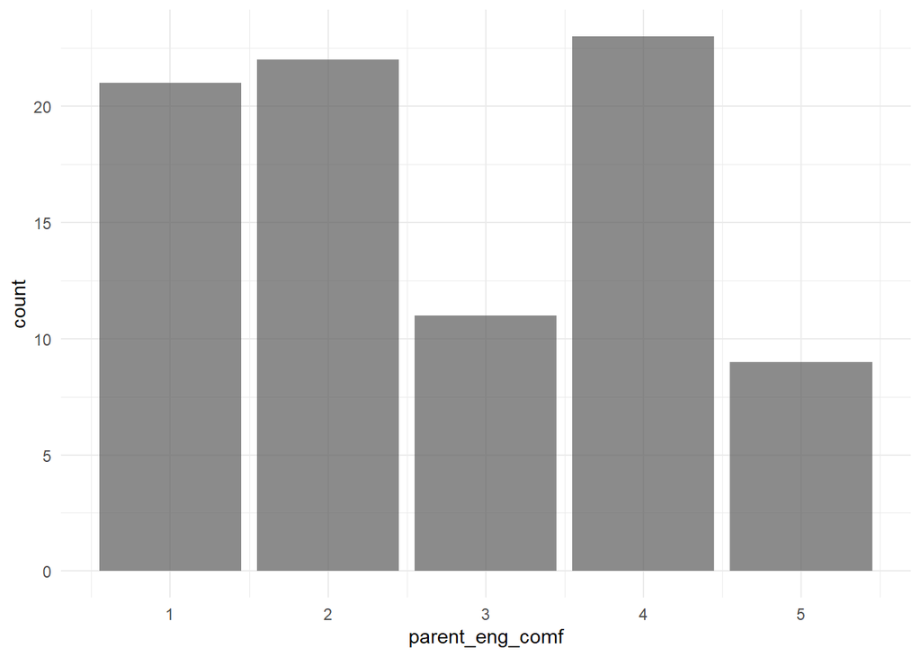

```r
ggplot(d1, aes(parent_eng_comf)) +
geom_bar(alpha = 0.7)
```

The expected youth-reported parent involvement value is 3.29, when we consider average values of all predictors in the model and student is male.

For every one-point increase in parents’ english comfort, youth-reported parent involvement decreases, on average, 0.17 and points. (is this interpretation correct?)

```r
# parental involvement: youth report
m5 <- lm(y_parinv ~ acadhwi_1 + checkhwi_1 + struct_1 + convfut_1 + knowschool_1 + parnets_1 + welcome_1 + endorse_1 + supported_1 + ptrel_1, d1)
summary(m5) # no relations
```

```
##
## Call:
## lm(formula = y_parinv ~ acadhwi_1 + checkhwi_1 + struct_1 + convfut_1 +
##     knowschool_1 + parnets_1 + welcome_1 + endorse_1 + supported_1 +
##     ptrel_1, data = d1)
##
## Residuals:
##     Min      1Q  Median      3Q     Max
## -1.5047 -0.4715  0.1751  0.5407  1.2692
##
## Coefficients:
##                Estimate Std. Error t value Pr(>|t|)
## (Intercept)   2.4740108  0.7951515   3.111  0.00256 **
## acadhwi_1     0.0748821  0.1443619   0.519  0.60536
## checkhwi_1    0.1325940  0.1281540   1.035  0.30388
## struct_1     -0.3028565  0.2725319  -1.111  0.26970
## convfut_1    -0.0810848  0.1271485  -0.638  0.52543
## knowschool_1  0.3173043  0.2098961   1.512  0.13445
## parnets_1    -0.0002393  0.1697116  -0.001  0.99888
## welcome_1     0.3674430  0.3082711   1.192  0.23672
## endorse_1    -0.1232058  0.3490978  -0.353  0.72505
## supported_1  -0.0676497  0.3783644  -0.179  0.85854
## ptrel_1      -0.2318350  0.2476139  -0.936  0.35188
## ---
## Signif. codes:  0 '***' 0.001 '**' 0.01 '*' 0.05 '.' 0.1 ' ' 1
##
## Residual standard error: 0.7333 on 82 degrees of freedom
##   (1 observation deleted due to missingness)
## Multiple R-squared:  0.07253,    Adjusted R-squared:  -0.04058
## F-statistic: 0.6413 on 10 and 82 DF,  p-value: 0.7744
```

```r
m5_cov <- lm(y_parinv ~ parent_eng_comf + youth_age + youth_gender + acadhwi_1 + checkhwi_1 + struct_1 + convfut_1 + knowschool_1 + parnets_1 + welcome_1 + endorse_1 + supported_1 + ptrel_1, d1)
summary(m5_cov) # parent eng conf negative and significant < 0.01, trends: knowschool < 0.10, welcome < 0.10
```

```
##
## Call:
## lm(formula = y_parinv ~ parent_eng_comf + youth_age + youth_gender +
##     acadhwi_1 + checkhwi_1 + struct_1 + convfut_1 + knowschool_1 +
##     parnets_1 + welcome_1 + endorse_1 + supported_1 + ptrel_1,
##     data = d1)
##
## Residuals:
##      Min       1Q   Median       3Q      Max
## -1.50245 -0.42574  0.07568  0.46417  1.23655
##
## Coefficients:
##                   Estimate Std. Error t value Pr(>|t|)
## (Intercept)      3.2887654  1.3761643   2.390  0.01955 *
## parent_eng_comf -0.1702686  0.0576494  -2.954  0.00428 **
## youth_age       -0.0446432  0.0962499  -0.464  0.64421
## youth_gender2    0.0504867  0.1576582   0.320  0.74975
## acadhwi_1        0.1488415  0.1498146   0.994  0.32389
## checkhwi_1       0.0923810  0.1432760   0.645  0.52118
## struct_1        -0.2929502  0.2615196  -1.120  0.26646
## convfut_1       -0.1276893  0.1227629  -1.040  0.30186
## knowschool_1     0.3583465  0.2075486   1.727  0.08866 .
## parnets_1        0.0005876  0.1661865   0.004  0.99719
## welcome_1        0.5292543  0.3115452   1.699  0.09380 .
## endorse_1        0.2152991  0.3467142   0.621  0.53664
## supported_1     -0.4062256  0.3867586  -1.050  0.29718
## ptrel_1         -0.3712332  0.2502874  -1.483  0.14250
## ---
## Signif. codes:  0 '***' 0.001 '**' 0.01 '*' 0.05 '.' 0.1 ' ' 1
##
## Residual standard error: 0.6755 on 70 degrees of freedom
##   (10 observations deleted due to missingness)
## Multiple R-squared:  0.2164, Adjusted R-squared:  0.07083
## F-statistic: 1.487 on 13 and 70 DF,  p-value: 0.1444
```